# Příklad rozpočtu

```r
library(tidyverse)
library(lubridate)
library(glue)
library(priceR)
```

Protože budu v kalkulaci nákladů pracovat se zahraničními měnami, stáhnu si nejprve aktuální kurzy CZK.

```r
exchange_rates <- exchange_rate_latest("CZK")
```

```
For full currency exchange rate API documentation visit:
 https://exchangerate.host/#/#docs
 (this message will only appear once per session)
```

```
Daily CZK exchange rate as at end of day 2022-03-18 GMT
```

Všechny náklady si sepíšu do přehledné tabulky s těmito sloupci:

- *name* – název položky,
- *cost* – částka bez DPH,
- *cur* – měna,
- *vatr* – sazba DPH,
- *period* – období, ke kterému se náklad vztahuje; může být ‘month’ (měsíc), ‘quarter’ (čtvrtletí), ‘year’ (rok),
- *month* – číslo měsíce v roce, ve kterém náklad poprvé naběhne,
- *day* – číslo dne v měsíci, ve kterém náklad naběhne,
- *pay_month* – počet měsíců po (kladné číslo), nebo před (záporné číslo), kdy je třeba zaplatit,
- *pay_day* – počet dní po (kladné číslo), nebo před (záporné číslo), kdy je třeba zaplatit.

```r
costs <- tribble(
  ~name,              ~cost,  ~cur, ~vatr, ~period,  ~month, ~day, ~pay_month, ~pay_day,
  "Mzdy",      70000 * 1.35, "CZK",     0, "month",       1,    1,          1,       15,
  "Účetnictví",     9300.00, "CZK",     0, "quarter",     1,   25,          0,        0,
  "O2",             1650.31, "CZK",    21, "month",       1,    1,          0,       10,
  "T-Mobile",        948.35, "CZK",    21, "month",       1,   10,          0,       10,
  "Toggl",            10.00, "USD",     0, "month",       1,    6,          0,        0,
  "Adobe",             9.99, "EUR",     0, "month",       1,    2,          0,        0,
  "Fakturoid",      5280.00, "CZK",    21, "year",        3,    1,          0,        7,
  "Google Cloud",     76.69, "USD",     0, "month",       1,    1,          0,        0,
  "Basecamp",         12.00, "USD",     0, "month",       1,   19,          0,        0,
  "Blueboard",      4000.00, "CZK",    21, "year",        1,    1,          0,       10,
  "Screaming Frog",  149.00, "GBP",     0, "year",        1,   20,          0,        0,
  "MindMeister",      50.00, "USD",     0, "year",        1,    5,          0,        0
)
costs
```

| name | cost | cur | vatr | period | month | day | pay_month | pay_day |
| --- | --- | --- | --- | --- | --- | --- | --- | --- |
| Mzdy | 94500.00 | CZK | 0 | month | 1 | 1 | 1 | 15 |
| Účetnictví | 9300.00 | CZK | 0 | quarter | 1 | 25 | 0 | 0 |
| O2 | 1650.31 | CZK | 21 | month | 1 | 1 | 0 | 10 |
| T-Mobile | 948.35 | CZK | 21 | month | 1 | 10 | 0 | 10 |
| Toggl | 10.00 | USD | 0 | month | 1 | 6 | 0 | 0 |
| Adobe | 9.99 | EUR | 0 | month | 1 | 2 | 0 | 0 |
| Fakturoid | 5280.00 | CZK | 21 | year | 3 | 1 | 0 | 7 |
| Google Cloud | 76.69 | USD | 0 | month | 1 | 1 | 0 | 0 |
| Basecamp | 12.00 | USD | 0 | month | 1 | 19 | 0 | 0 |
| Blueboard | 4000.00 | CZK | 21 | year | 1 | 1 | 0 | 10 |

[output cut: 2 more lines]

Z tabulky *costs* si nyný vygeneruji tabulku *cost_by_date*, která bude v daném roce obsahovat jedlivé nákladové položky v každém dni, kdy naběhnou. Ve výsledné tabulce nechám jen ty sloupce, které budu potřebovat pro výpočet měsíčních nákladů a pro výpočet cash flow.

```r
year <- 2022

costs_by_date <- costs |>
  left_join(exchange_rates, by = c("cur" = "currency")) |>
  rename(ex_rate = last_col()) |>
  mutate(
    cost_czk = round(cost / ex_rate, 2),
    vat = round(cost_czk * (vatr / 100), 2)
  ) |>
  rowwise() |>
  mutate(
    date = list(seq(make_date(year, month, day), make_date(year, 12, 31), by = period))
  ) |>
  ungroup() |>
  unnest_longer(date) |>
  select(date, cost_czk, vat, pay_month, pay_day)

costs_by_date
```

| date | cost_czk | vat | pay_month | pay_day |
| --- | --- | --- | --- | --- |
| 2022-01-01 | 94500.00 | 0.00 | 1 | 15 |
| 2022-02-01 | 94500.00 | 0.00 | 1 | 15 |
| 2022-03-01 | 94500.00 | 0.00 | 1 | 15 |
| 2022-04-01 | 94500.00 | 0.00 | 1 | 15 |
| 2022-05-01 | 94500.00 | 0.00 | 1 | 15 |
| 2022-06-01 | 94500.00 | 0.00 | 1 | 15 |
| 2022-07-01 | 94500.00 | 0.00 | 1 | 15 |
| 2022-08-01 | 94500.00 | 0.00 | 1 | 15 |
| 2022-09-01 | 94500.00 | 0.00 | 1 | 15 |
| 2022-10-01 | 94500.00 | 0.00 | 1 | 15 |

[output cut: 82 more lines]

Nyní si vytvořím tabulku odhadovaných výnosů *revenue_by_date*. Bude se jednat o výnosy za měsíc, naběhnou v poslední den každého měsíce a splatné budou o 15 dní později. Vypočítají se s odhadu fakturovaných hodin vynásobených hodinovou saznou. Počet fakturovaných hodin bude náhodně fluktuovat +/- 5 hodin okolo průměru. DPH je 21 %.

```r
average_hours <- 45
hourly_rate <- 2500

revenue_by_date <- tibble(
  date = seq(make_date(year, 2, 1), length = 12, by = "month") - 1,
  revenue = round(runif(12, average_hours - 5, average_hours + 5)) * hourly_rate,
  vat =  revenue * 0.21,
  pay_month = 0,
  pay_day = 15
)

revenue_by_date
```

| date | revenue | vat | pay_month | pay_day |
| --- | --- | --- | --- | --- |
| 2022-01-31 | 115000 | 24150 | 0 | 15 |
| 2022-02-28 | 107500 | 22575 | 0 | 15 |
| 2022-03-31 | 105000 | 22050 | 0 | 15 |
| 2022-04-30 | 112500 | 23625 | 0 | 15 |
| 2022-05-31 | 115000 | 24150 | 0 | 15 |
| 2022-06-30 | 112500 | 23625 | 0 | 15 |
| 2022-07-31 | 120000 | 25200 | 0 | 15 |
| 2022-08-31 | 105000 | 22050 | 0 | 15 |
| 2022-09-30 | 112500 | 23625 | 0 | 15 |
| 2022-10-31 | 112500 | 23625 | 0 | 15 |

[output cut: 2 more lines]

Tabulky *costs_by_date* a *revenue_by_date* spojím a areguji podle měsíce (prvního dne v měsíci). Pak vypočítám zisk jako rozdíl výnosů a nákladů a výsledek zobrazím v grafu měsíčního a kumulovaného zisku.

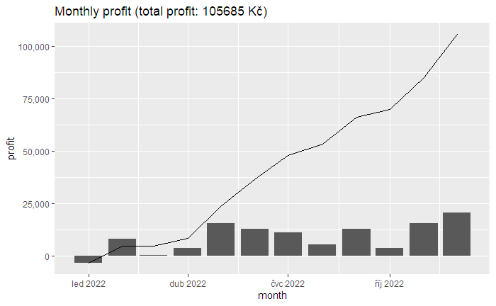

```r
profit_by_month <- costs_by_date |>
  bind_rows(revenue_by_date) |>
  group_by(month = floor_date(date, unit = "month")) |>
  summarise(
    cost = sum(cost_czk, na.rm = TRUE),
    revenue = sum(revenue, na.rm = TRUE),
    profit = round(revenue - cost)
  )

profit_by_month |>
  ggplot(aes(x = month, y = profit)) +
  geom_col() +
  geom_line(aes(y = cumsum(profit))) +
  scale_y_continuous(labels = scales::comma) +
  labs(title = glue("Monthly profit (total profit: {round(sum(profit_by_month$profit))} Kč)"))
```

[figure not shown]

```r
hours_for_profit <- function(annual_profit, hourly_rate, costs) {
  r <- uniroot(
    function(x) {
      x * hourly_rate - (sum(costs$cost_m) * 12) - annual_profit
    },
    c(12, 200 * 12)
  )
  r$root / 12
}
```

```r
hours_for_profit(100000, 2500, costs)
```

```
[1] 44.88531
```

```r
profit_in_year <- function(average_hours, hourly_rate) {
  monthly <- tibble(
    month = seq(ymd("2022-01-01"), ymd("2022-12-31"), by = "month"),
    costs = sum(costs$cost_m),
    hours = round(runif(12, average_hours - 5, average_hours + 5)),
    hourly_rate = hourly_rate,
    revenue = hours * hourly_rate,
    profit = round(revenue - costs)
  )
  monthly |>
    ggplot(aes(x = month, y = profit)) +
    geom_col() +
    labs(title = glue("Monthly profit (total profit: {sum(monthly$profit)} Kč)"))
}
```

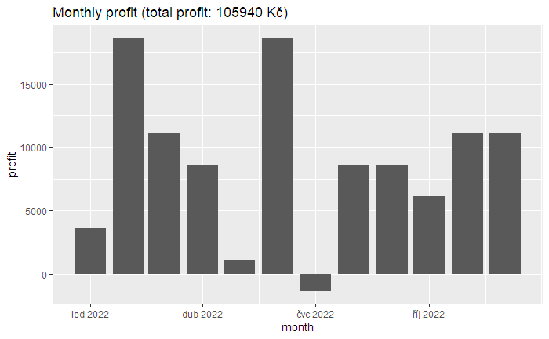

```r
profit_in_year(45, 2500)
```